# Introducing the introduction

Structural Equation Modeling

Tommaso Feraco

## Topics that we will (hopefully) cover in the course

1. `lavaan`
2. Basic knowledge about SEM
3. Models with manifest variables - path analysis
4. Measurement models with SEM - CFA
5. Full SEM: measurement + structural part
6. Model invariance - MG-CFA
7. Handling missing data
8. Models for ordinal data
9. Other miscellaneous topics (interactions, power analysis, MASEM)

## Why am I here?

I am convinced that SEM is a fundamental tool for research in psychology and most, if not all, researchers in this area should know it. Indeed, it is key for many aspects of your research:

- Measurement
- Multivariate analyses
- Complex regression models
- Longitudinal analyses
- …
- Understanding causality from a measurement perspective

## What you can expect from this course

I am not a statisticians. This will have negative consequences on your statistical knowledge at the end of the course, but hopefully more practical and psychology-based examples and experiences.

- Practical example
- Data simulation
- Few equations
- Open discussions
- Hands-on your data

## What you need

- A PC (optional)
- Basic R knowledge
- Some packages installed

```r
install.packages(c("lavaan", "semTools", "semPlot", # IMPORTANT
                   "modsem", "MASS")) # FACULTATIVE
```

## Materials and organization

- For each argument you will find
- Slides
- Additional code
- Data
- We will probably do live coding when needed. I will eventually upload those data on github.

# Introduction

## How do you fit these?

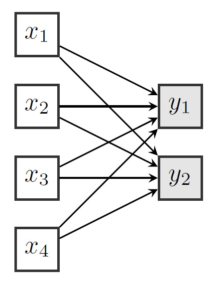

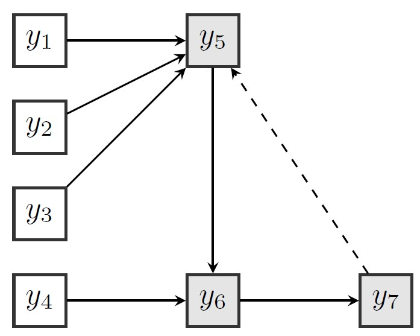

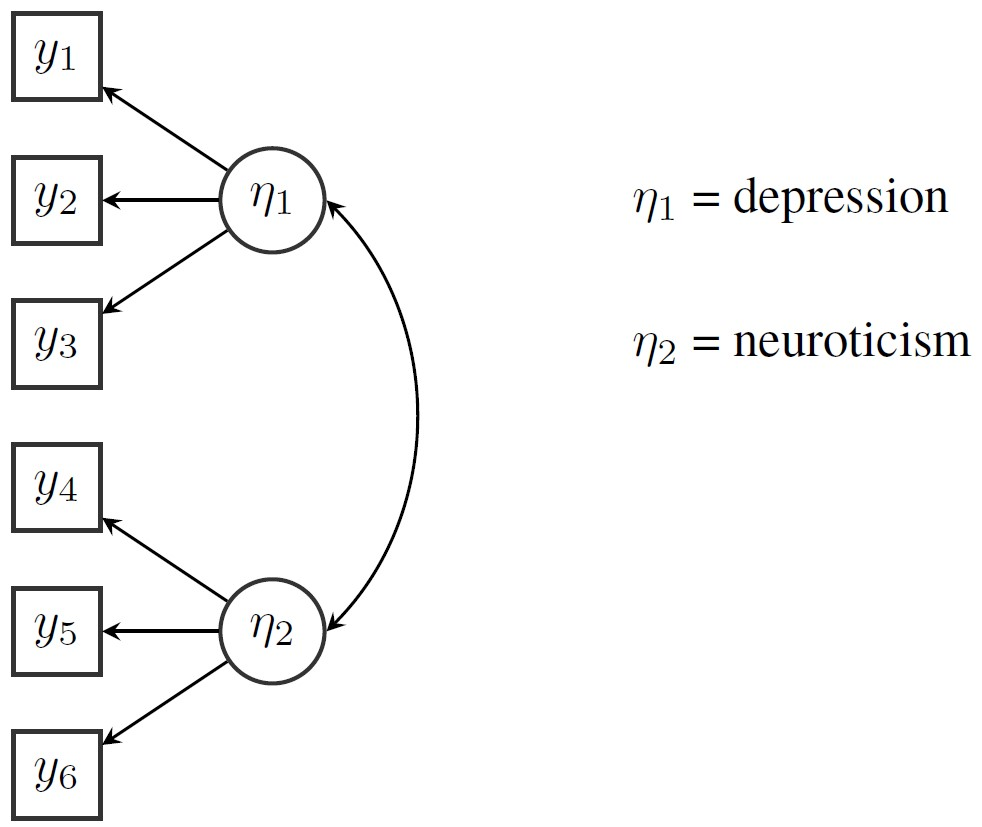

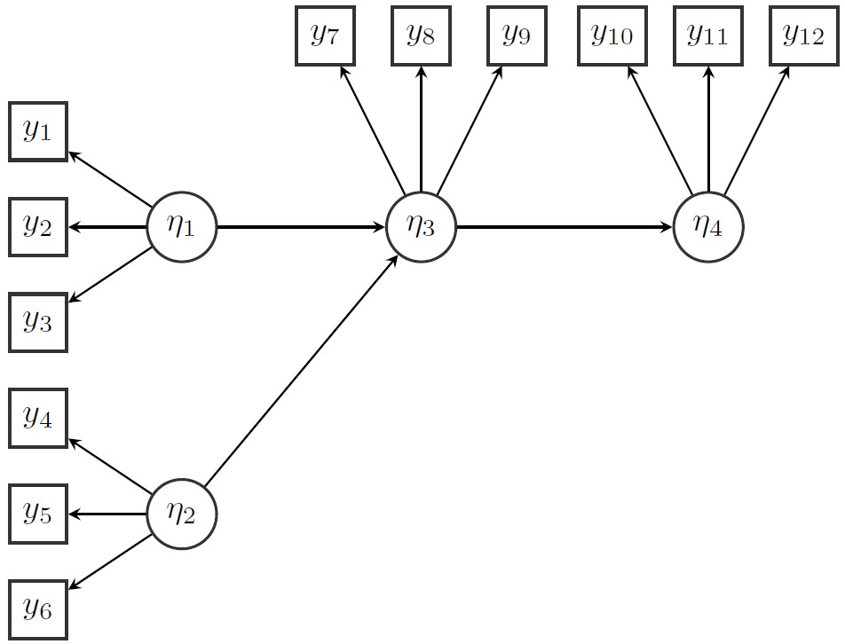

## SEM = Structural Equation Modeling

- SEM is a multivariate statistical modeling technique
  - it includes path-analysis, causal models, factorial models, measurement models, Latent Growth Models, but even simple multiple regression or ANOVA could be considered particular cases of SEM.
  - All these techniques **use the covariance matrix** ($\boldsymbol{S}$) for estimating target model parameters.
- SEM allows us to test a hypothesis/model about the data
  - we postulate a data-generating model
  - we evaluate whether this model fits the data or not
- What is so special about SEM?
  - we can model latent variables (e.g., ‘invisible constructs’)
  - we can test indirect and reciprocal effects and more
  - last but not least, we can make diagrams (or PAINTINGS if theory is weak!)

## Variance-covariance matrices

```r
options(digits = 2)
cov(PoliticalDemocracy[1:7])
```

```
    y1   y2   y3   y4  y5   y6   y7
y1 6.9  6.3  5.8  6.1 5.1  5.7  5.8
y2 6.3 15.6  5.8  9.5 5.6  9.4  7.5
y3 5.8  5.8 10.8  6.7 4.9  4.7  7.0
y4 6.1  9.5  6.7 11.2 5.7  7.4  7.5
y5 5.1  5.6  4.9  5.7 6.8  5.0  5.8
y6 5.7  9.4  4.7  7.4 5.0 11.4  6.7
y7 5.8  7.5  7.0  7.5 5.8  6.7 10.8
```

SEM works with matrices

- $\boldsymbol{S}$ observed var-cov
- $\boldsymbol{\Sigma}$ true var-cov
- $\boldsymbol{\hat{\Sigma}}$ model-implied var-cov
- $\boldsymbol{\Sigma}(\theta)$

`THE MAIN AIM OF SEM IS TO RECONSTRUCT THE TRUE VARIANCE-COVARIANCE MATRIX`

## Classification of variables

Variables are the way those attributes that **vary** across individuals are operationalized and represented for further data processing. These can be categorized according to many criteria (e.g, *dependent/independent*…), but in SEM we classify them firstly as:

- **Latent variables**
  - hypothetical variables that correspond to more or less abstract concepts
  - formative or reflective
  - examples are intelligence, anxiety, executive functions, personality traits…
- **Observed variables**
  - variables that can be directly observed and measured
  - examples can be weight, height, gender, income…

## Classification of variables

In SEM we also have an additional type of classification:

- **Exogenous variables**
  - Variables whose causes lie outside the model; they will be used only as predictors in the model. They do not receive arrows.
  - They are indicated with $x$, if observed, or with $\xi$, if latent.
- **Endogenous variables**
  - Variables that are determined by variables within the model (they receive arrows); can be used as predictors or dependent variables in the model.
  - They are indicated with $y$, if observed, or with $\eta$, if latent.

This brings us to deepen the relationships between variables.

## Relationships between variables

- The general aim of statistical analysis is to study relationship among variables
- On the basis of the relationship among the variables, we distinguish two kind of models:
  - symmetrical
  - asymmetrical

## Asymmetrical relationships

$X \rightarrow Y$

- Variables are divided into two sets: dependent or response variables and predictors or explanatory variables
- *X* is the set of explanatory variables, $Y$ is the set of response variables, arrows represents the direction of the hypothesized relationship.
- These models imply cause-and-effect relationships.

**Example**

People who study more obtain higher grades.

## Symmetrical relationships

$$X_i \Leftrightarrow Y_j \quad \forall i,j$$

- This means that neither a variable *causes* the other, neither a variable can be considered *prior* in time to the other; all these relationships are bidirectional.
- These models do not imply nor consider causality.

**Example**

People who have higher grades in math have higher grades in art.

## Regression model

Asymmetrical relationships are usually tested with regressions!

As you remember, regression models can be written, using classical formulation and graphically depicted (getting closer to SEM) like this:

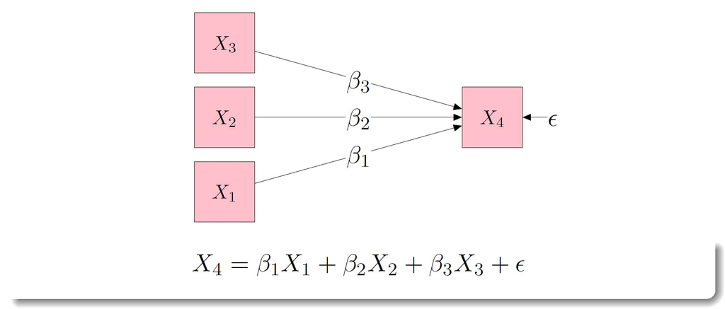

## More regressions?

But what if we have in mind a more complex pattern of relationships? What if we have more regression models in mind and need to estimate all of them contemporarily?

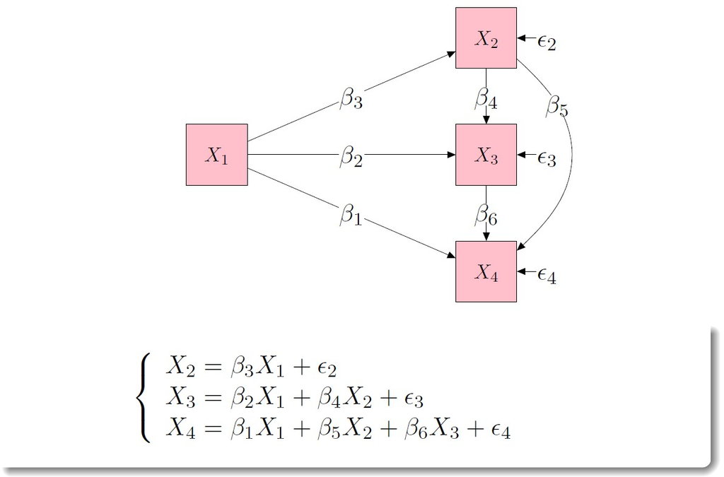

What we need is a system of equations.

## More regressions?

This system can also be drawn with SEM notation, but is actually the same…just *better*!

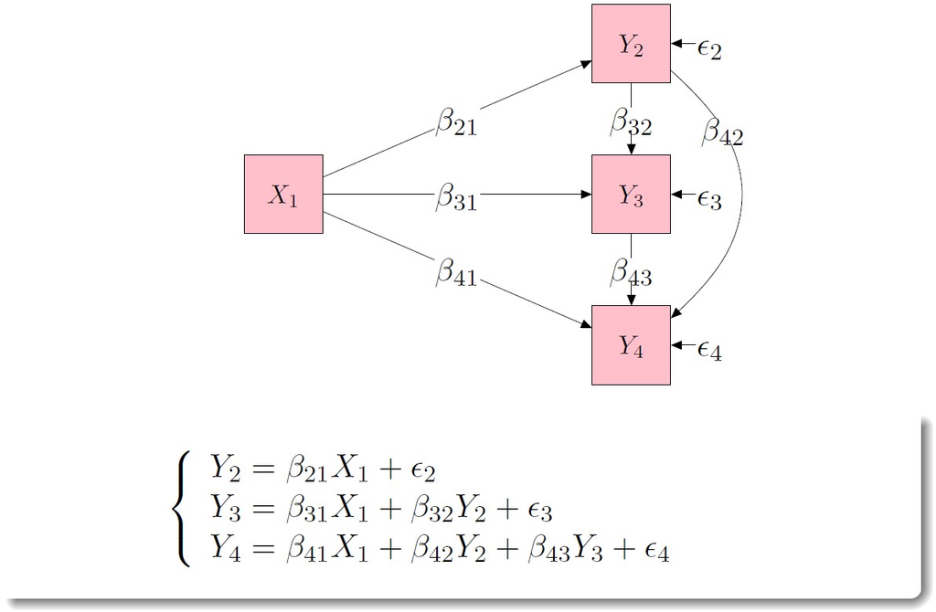

## Covariance matrix

The covariance matrix is the input for the estimation process. In general, given $q$ exogenous ($x$) and $p$ endogenous ($y$) variables, the covariance matrix will be:

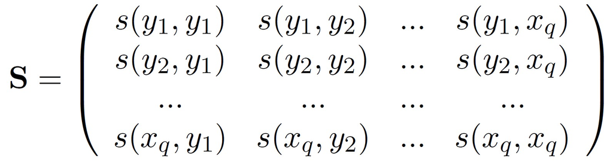

In which the diagonal elements are variances and off diagonal elements are covariances.

## Variables and errors

- **Variables**
  - $x$ exogenous observed ($q$)
  - $\xi$ exogenous latent ($n$)
  - $y$ endogenous observed ($p$)
  - $\eta$ endogenous latent ($m$)
- **Stochastic errors**
  - $\delta$ measurement errors in $x$
  - $\epsilon$ measurement errors in $y$
  - $\zeta$ equation errors in the structural relationship between $\eta$ and $\xi$

## SEM matrices - lavaan model

- **Parameter matrices**
  - $\boldsymbol{\Lambda}$ relationship between latent ($\xi$ and $\eta$) and observed ($x$ and $y$) [$(p + q) X (m + n)$]
  - $\boldsymbol{B}$ relationship between latent variables [$(m + n) X (m + n)$]
- **Covariance matrices**
  - $Cov$($\zeta$, $\xi$) = $\boldsymbol{\Psi}$ matrix [$(m + n) X (m + n)$]
  - $Cov$($\epsilon$, $\delta$) = $\boldsymbol{\Theta}$ matrix [$(p + q) X (p + q)$]

## SEM equations

The SEM model in its most general form consists of two parts

- **The measurement model**
  - $x = \boldsymbol{\Lambda}_x\boldsymbol{\xi} + \boldsymbol{\delta}$
  - $y = \boldsymbol{\Lambda}_y\boldsymbol{\eta} + \boldsymbol{\epsilon}$
- **The structural model**
  - $\boldsymbol{\eta} = \boldsymbol{B\eta} + \boldsymbol{\Gamma\xi} + \boldsymbol{\zeta}$
  - $\boldsymbol{\eta} = \boldsymbol{B(\eta\xi} + \boldsymbol{\zeta})$

## SEM steps

There are 5 principal steps in Structural Equation Modeling:

1. model specification
2. model identification
3. parameters estimation
4. testing
5. model modification

As usual, these steps are like a cycle: when you arrive at step 5 you can always come back to step 1.

## 1. Model specification

**Aim of the model**

- We fit models because we want to better understand the data and the process of data generation (to better understand this we will use simulation…simulate, simulate, simulate!)

**What is a model**

- A model is a formal representation of a theory and is composed by a set of parameters that we will estimate.

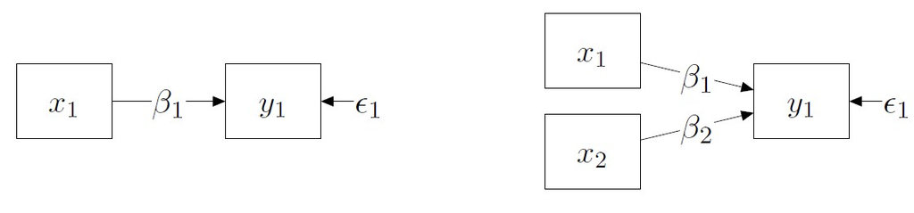

## 2. Model identification

Basically, we want to know if there is enough information to identify a solution (aka estimate all the unknown parameters).

A model can be:

- **Under-identified**
- **Just-identified**
- **Over-identified**

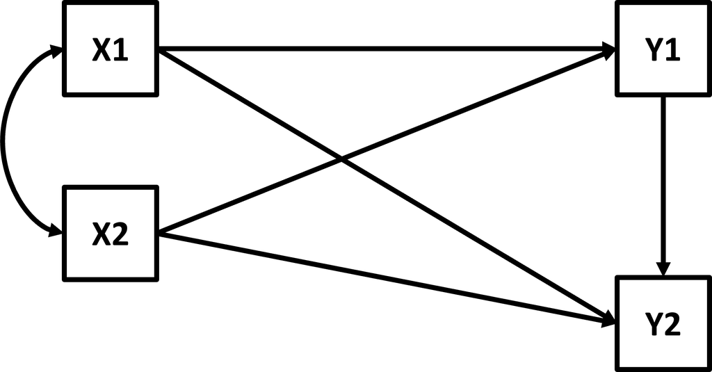

## 2. Model identification

Basically, we want to know if there is enough information to identify a solution (aka estimate all the unknown parameters).

A model can be:

- **Under-identified**: there are MORE parameters to be estimated than elements in the covariance matrix (e.g., $X + Y = 10$)
- **Just-identified**: the number of parameters to be estimated equals the number of elements in the covariance matrix ($df = 0$)
- **Over-identified**: there are LESS parameters to be estimated than elements in the covariance matrix ($df > 0$)

## 3. Model identification

To ensure that the number of unknown parameters ($t$) is not greater than the number of nonredundant elements in the covariance matrix of $q$ observed variables. We can use the following formula:

$$t \leq \frac{q(q+1)}{2}$$

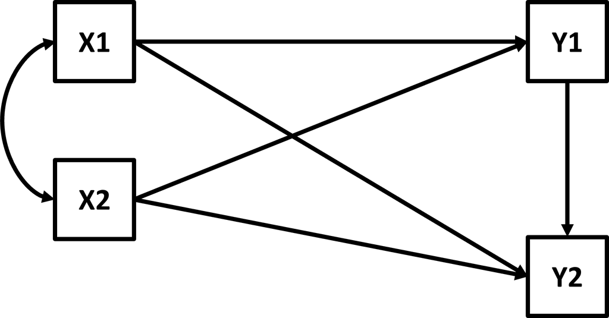

## An under-identified model

To ensure that the number of unknown parameters ($t$) is not greater than the number of nonredundant elements in the covariance matrix of $q$ observed variables. We can use the following formula:

$$t \leq \frac{q(q+1)}{2}$$

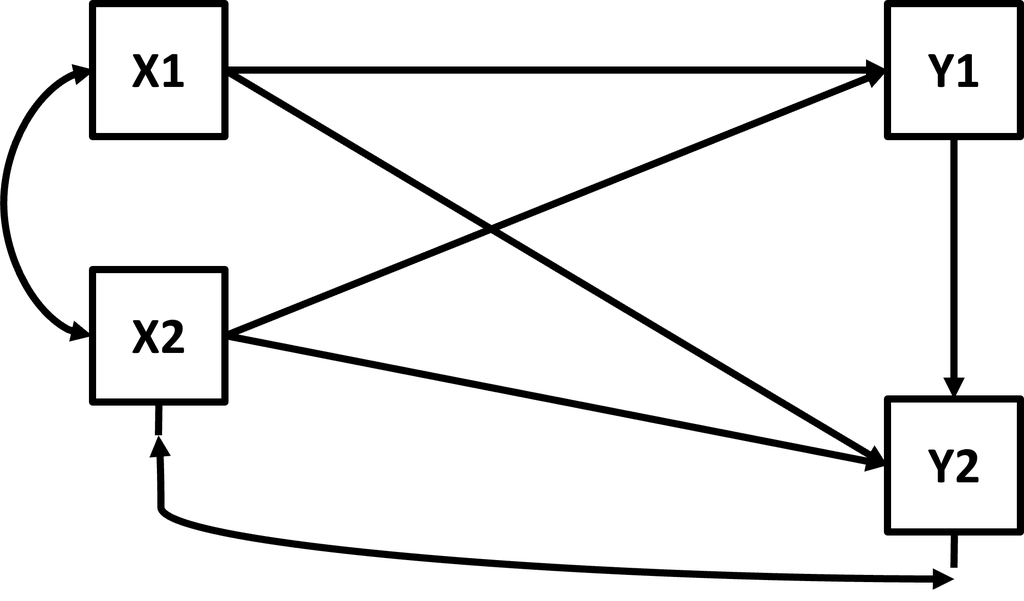

## An over-identified model

To ensure that the number of unknown parameters ($t$) is not greater than the number of nonredundant elements in the covariance matrix of $q$ observed variables. We can use the following formula:

$$t \leq \frac{q(q+1)}{2}$$

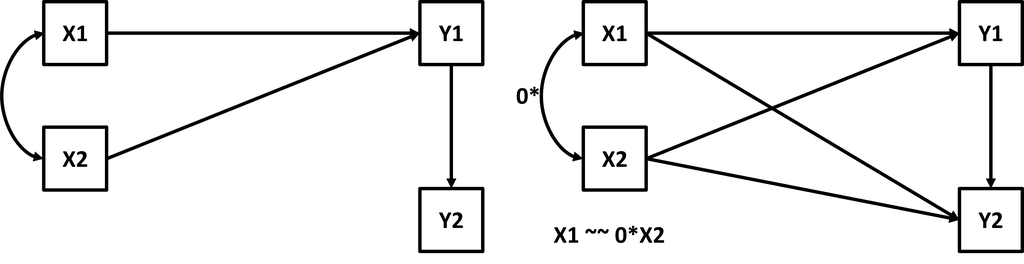

## 3. Parameter estimation

To estimate the model parameters we can use different estimation methods. These aim to estimate the model implied (theoretical) correlation matrix $\boldsymbol{\Sigma}$, which is a function of the model parameters, and should hopefully be similar to the observed correlation matrix $\boldsymbol{S}$.

**Some of the many estimation methods are:**

- Maximum Likelihood (ML), default in lavaan
- Unweighted Least Squares (ULS)
- Generalized Least Squares (GLS)
- Diagonally Weighted Least Squares (DWLS), default for ordinal variables in lavaan

## 4. Model evaluation

Is the model adequate? Are our parameter able to construct a theoretical matrix ($\boldsymbol{\Sigma}$) which is close to the original empirical covariance matrix $\boldsymbol{S}$?

This is the goal of a good model: reproduce, from a set of theoretical associations/effects (aka covariance matrix), the original covariance matrix.

Formally:

$$H_0 : \boldsymbol{\hat{\Sigma}}(\theta) = \boldsymbol{\Sigma}$$
where $\boldsymbol{\Sigma}$ is the true covariance matrix among model variables, $\theta$ the parameters vector, and $\boldsymbol{\hat{\Sigma}}$ the reproduced covariance matrix.

## 5. Model modification

At this point you are free to modify the model based on the results obtained…**AND THE THEORY!**

## A full representation

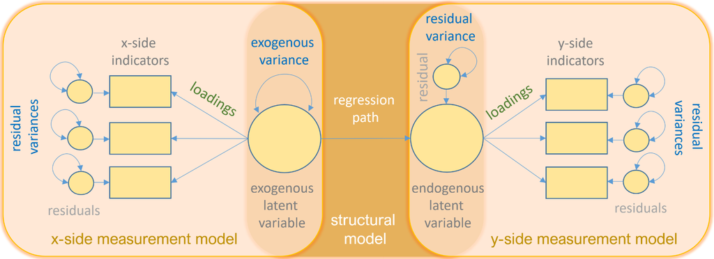

img credits to dr. Johnny Lin (youtube [course](https://www.youtube.com/watch?v=2M6VQY_OFvM))

## Graphical representation

If that all seemed difficult and boring, now comes the funny part: colors, figures, and arrows!

Graphical representation is a key attribute of structural equation modeling:

- It helps understanding the model
- It helps thinking and reasoning about the model (a priori)
- It helps writing and formalizing the model
- It is easy, but few rules must be followed to have a readable model

## Graphical representation

- Latent variables are circles or ellipses

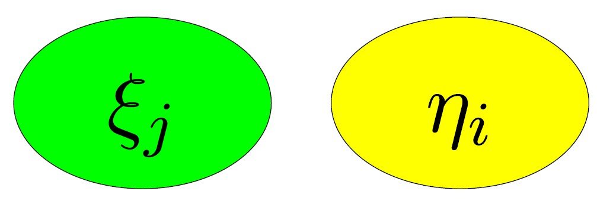

- Manifest/observed variables are square or rectangular boxes

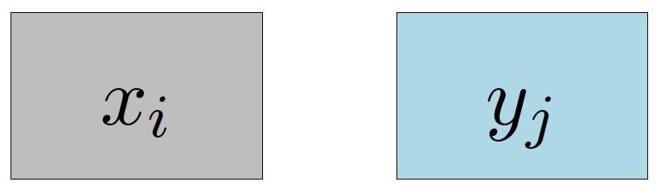

- Errors are represented by corresponding letters (or values) only

$$\delta_1 / \epsilon_1 / \zeta_1$$

## Graphic relationships

- All model relationships are represented by arrows;

**Warning**

NO relationship NO arrow… …and usually NO arrow NO relationship

- Each arrow is a model parameter and has two indices (e.g., $\beta_{21}$)
- **Asymmetrical relationship** are represented by a single headed arrow: the first index indicates the variable the arrow is pointing to, the second index indicates the variable of origin.
- **Symmetrical relationships** are represented by double-headed arrows and two indices, one for each variable.

## Graphic relationships

**A summary**

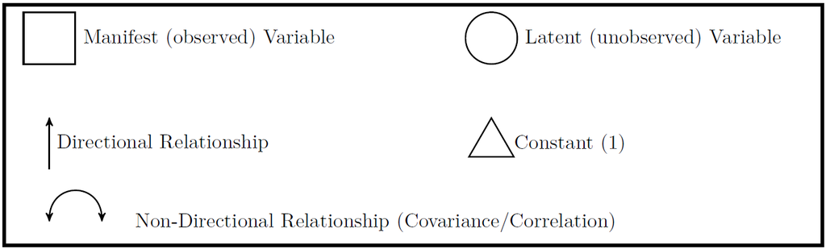

## Asymmetrical relationships

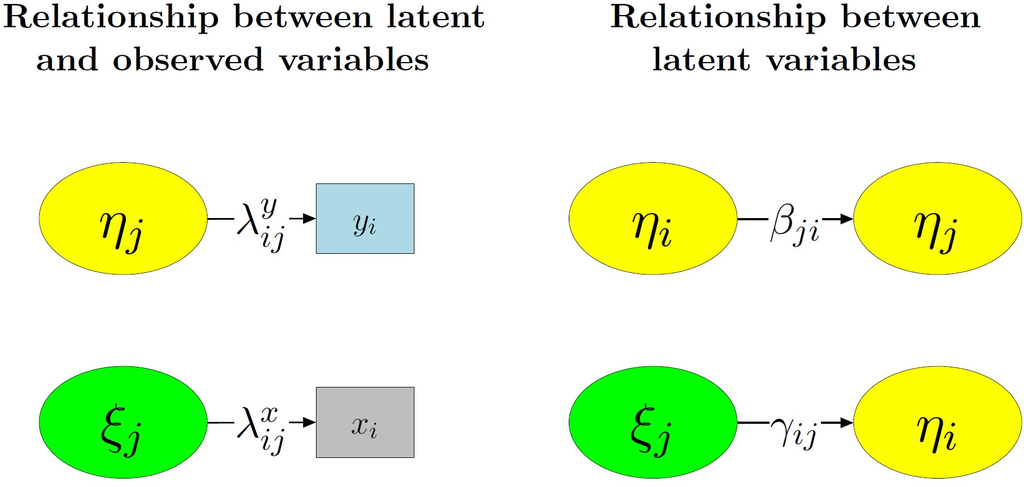

## Symmetrical relationships

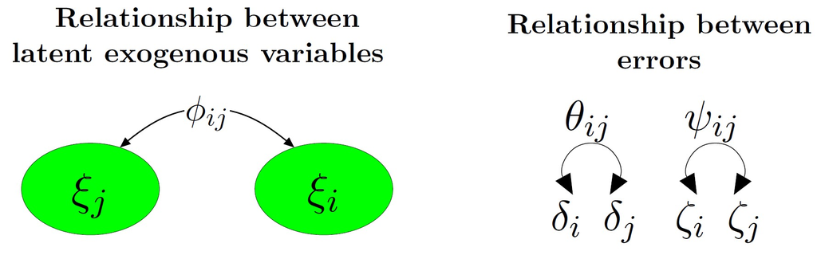

## Graphical errors

- All **errors** have a single headed arrow pointing to a variable; all variables, except $\xi$, may have an error.
- Double-headed arrows associated to errors indicate error variances.

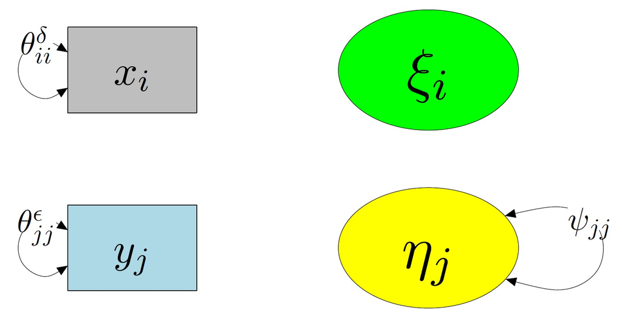

## A full representation

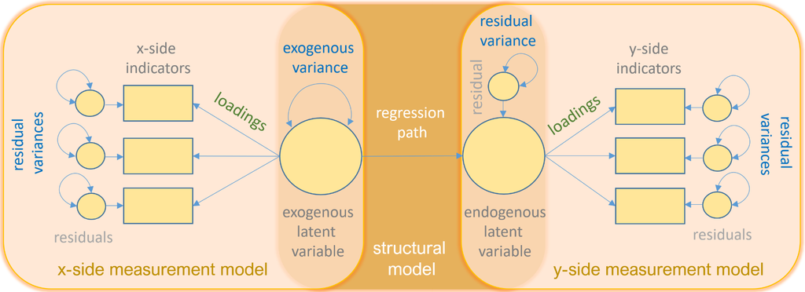

img credits to dr. Johnny Lin (youtube [course](https://www.youtube.com/watch?v=2M6VQY_OFvM))

# SEM exemplars

## Univariate regressions

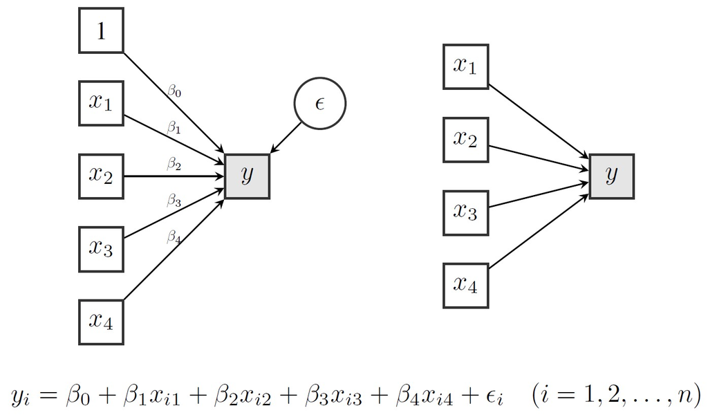

## Multivariate regressions

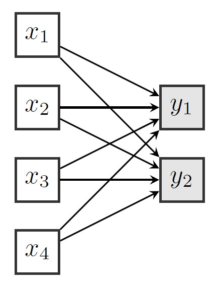

## Path analysis

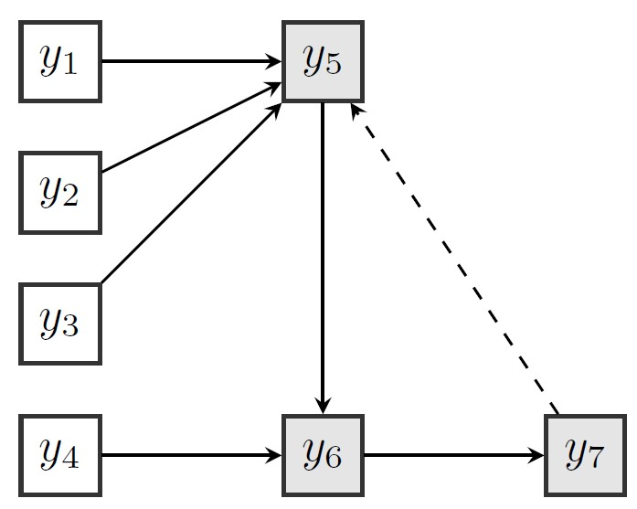

## Confirmatory factor analysis (CFA)

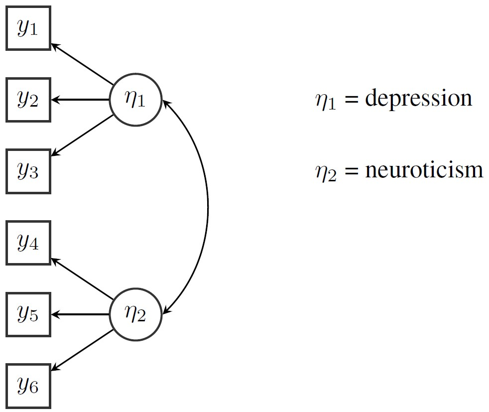

## SEM path analysis

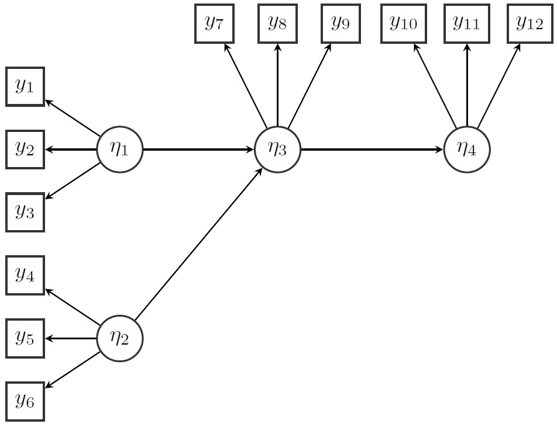

## t test with latent variables

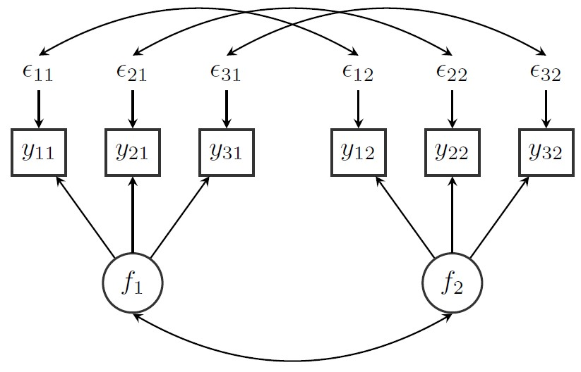

## Cross-lagged panel models

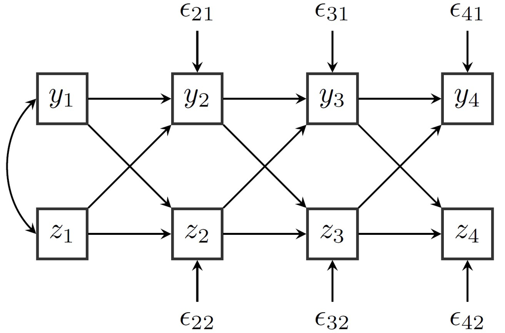

## Growth curve models

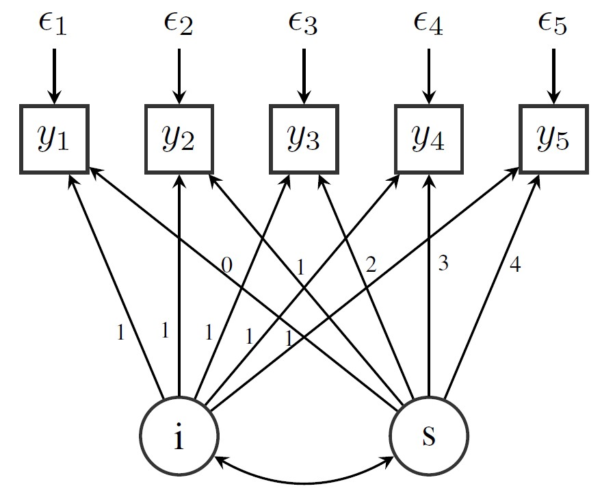

## And much more

`THERE IS EVEN A JOURNAL ONLY FOR SEM`

Structural Equation Modeling: A Multidisciplinary Journal

## Acknowledgments

Thanks to Massimiliano Pastore for his slides!

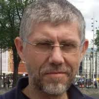

[figure not shown]